# Oxygen

Mégane

2023-05-08

## EOL - oxygen time series trend analysis by residuals (substracting climatological monthly means) - jan.2018 - nov.2022

*Analysis without interpolations*

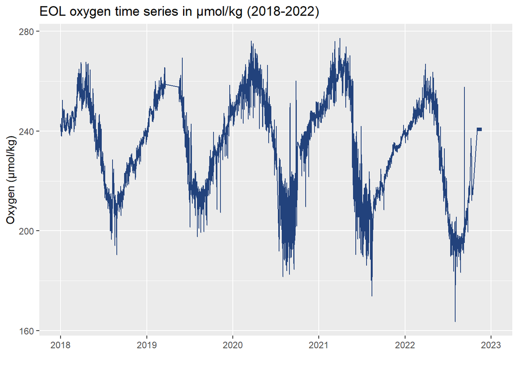

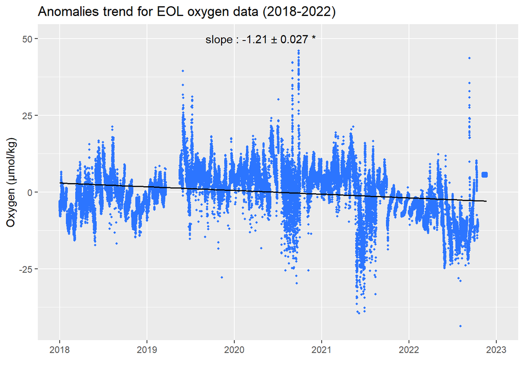

## Point B - oxygen time series trend analysis by residuals (substracting climatological monthly means)

*Analysis with interpolations*

###### → surface data (1m) : same results as raw

→ Trend analysis by residuals (Bates et al. 2014) :

Observed dissolved oxygen : positive trend (Garcia et al., 2005)  
*slope : 0.33 ± 0.061 μmol/kg per year*

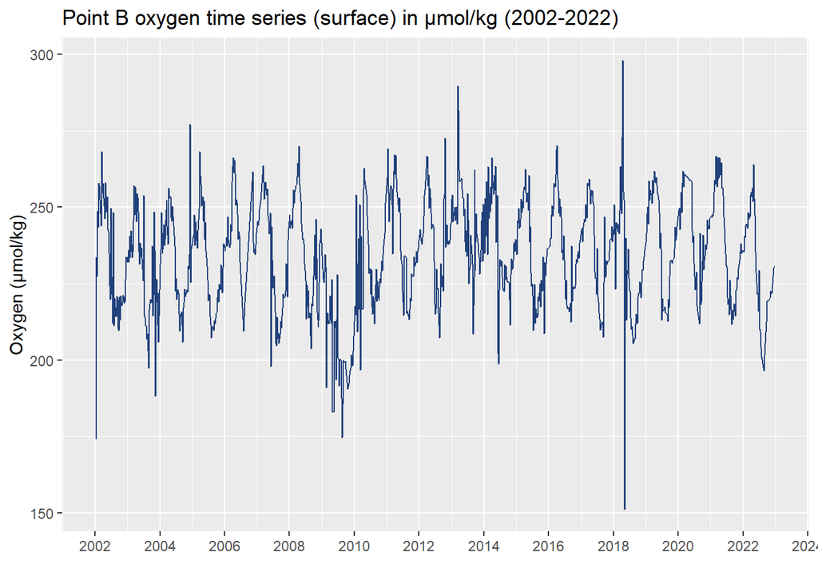

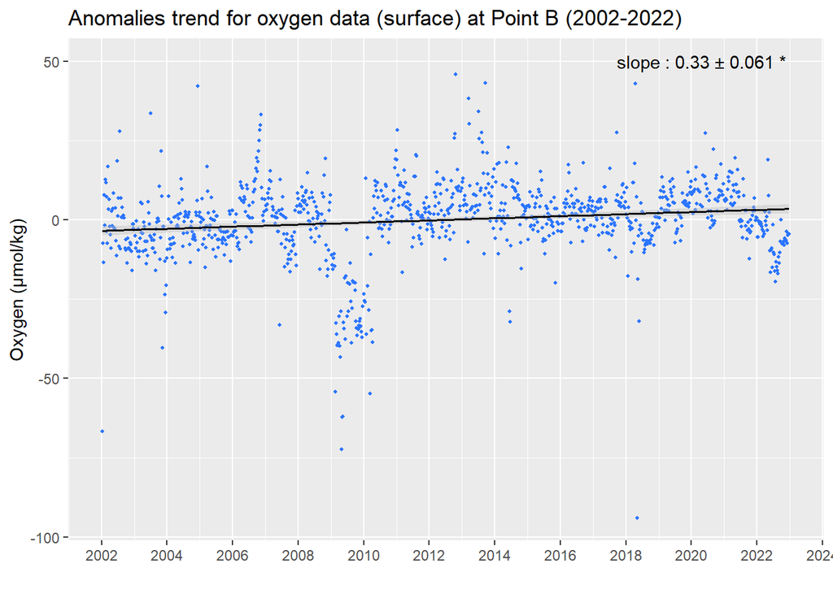

###### → 50 m data : same results as raw data

→ Trend analysis by residuals (Bates et al. 2014) :

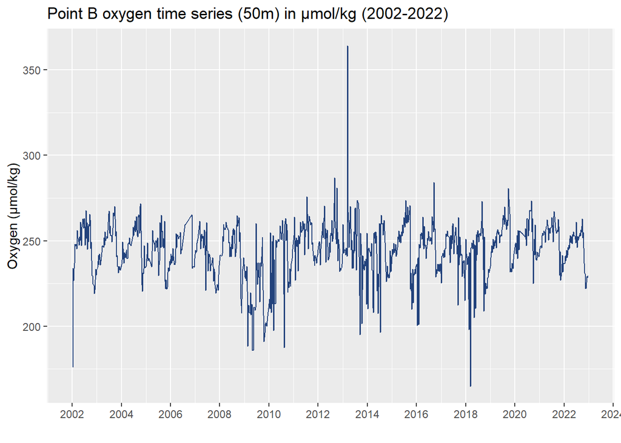

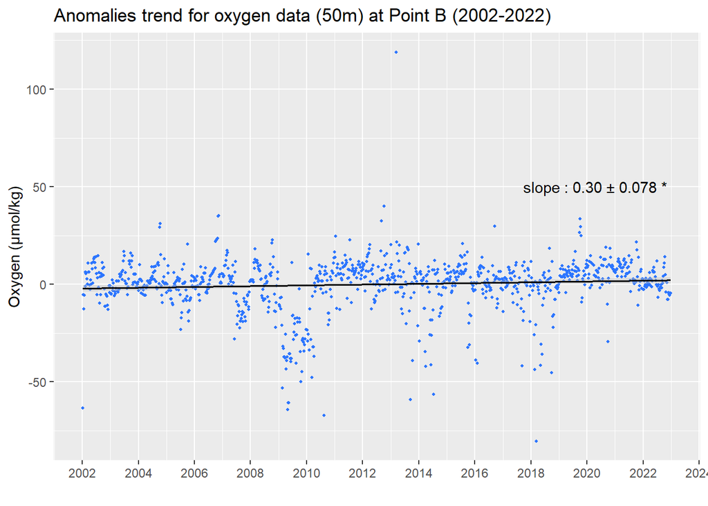

## EOL : AOU calculation (Apparent Oxygen Utilisation) :

Period : jan.2018 - nov.2022

AOU = [O<sub>2</sub> saturation] in µmol/kg - [O<sub>2</sub> observed] in µmol/kg  
Unity : µmol/kg

→ AOU (EOL) annual cycle :

AOU : valeurs majoritairement négatives = *plus faibles valeurs en été*

Shifts : 2020 and 2021

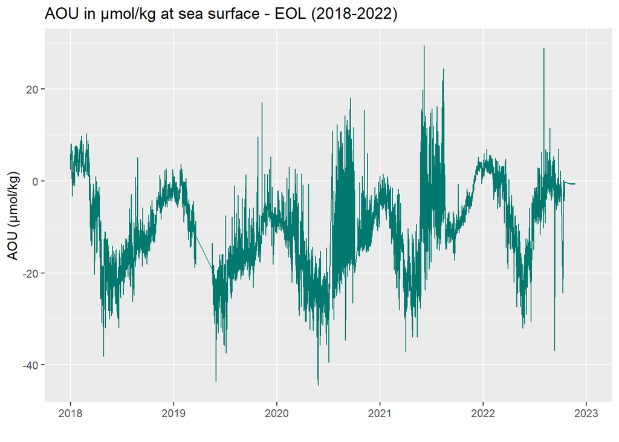

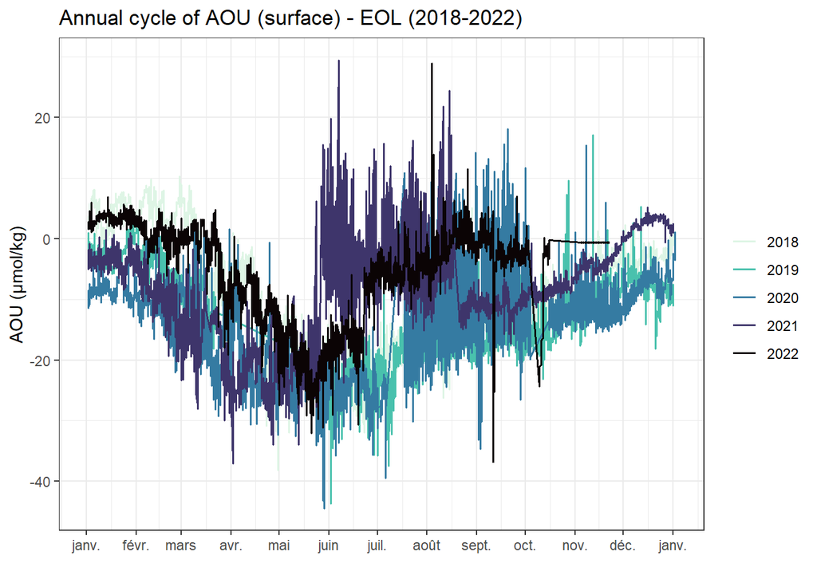

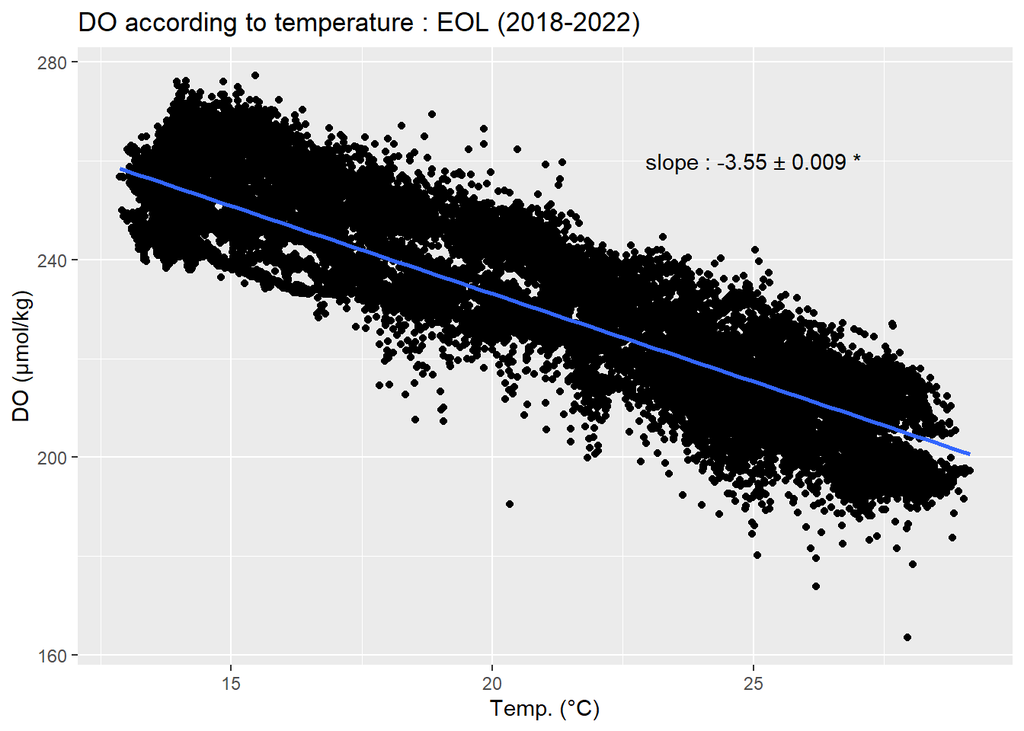

###### Trend analysis by residuals - AOU - EOL (Bates et al. 2014) :

Positive trend :  
*slope : 1.34 ± 0.023 µmol/kg per year*

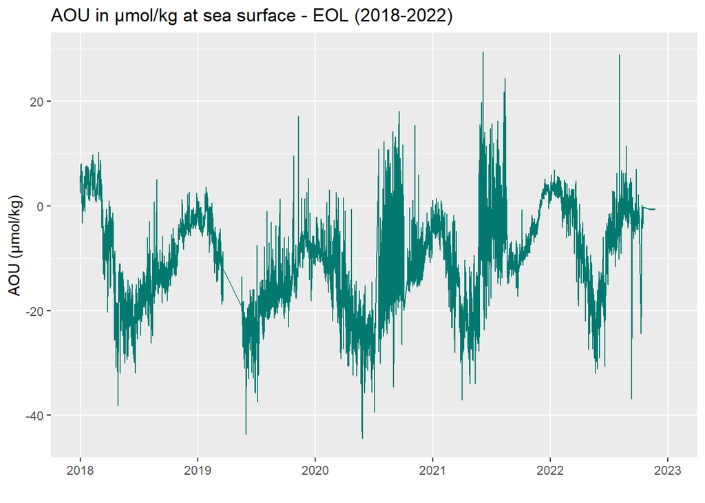

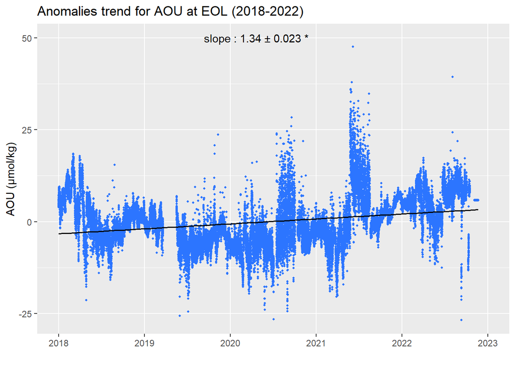

→ Plot mean annual anomalies of O<sub>2</sub>, O<sub>2</sub>sat and negative AOU (Mavropoulou et al., 2020)

→ thus, the solubility changes have a secondary role in the observed dissolved oxygen variations

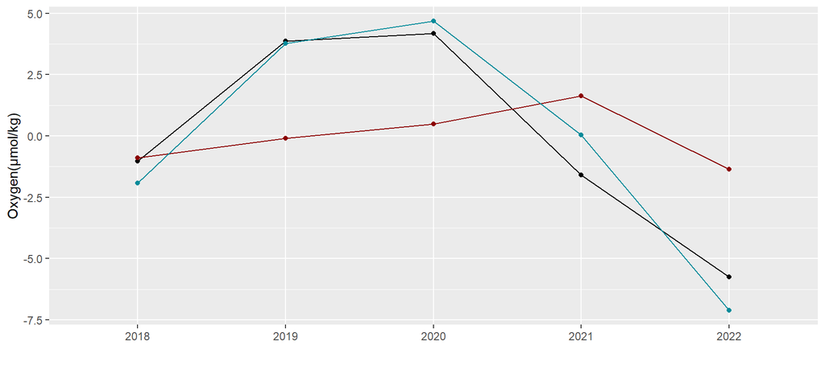

## Point B - AOU calculation (Apparent Oxygen Utilisation) :

AOU = [O<sub>2</sub> saturation] in µmol/kg - [O<sub>2</sub> observed] in µmol/kg  
Unity : µmol/kg

OSAT : driven by temperature

AOU removes the effect of OSAT, which is primarily driven by temperature

###### → surface data (1m) :

→ AOU (surface) annual cycle : low values in summer

Temperature and DO are correlated (r = -0.66) : when temp. increases, DO decreases

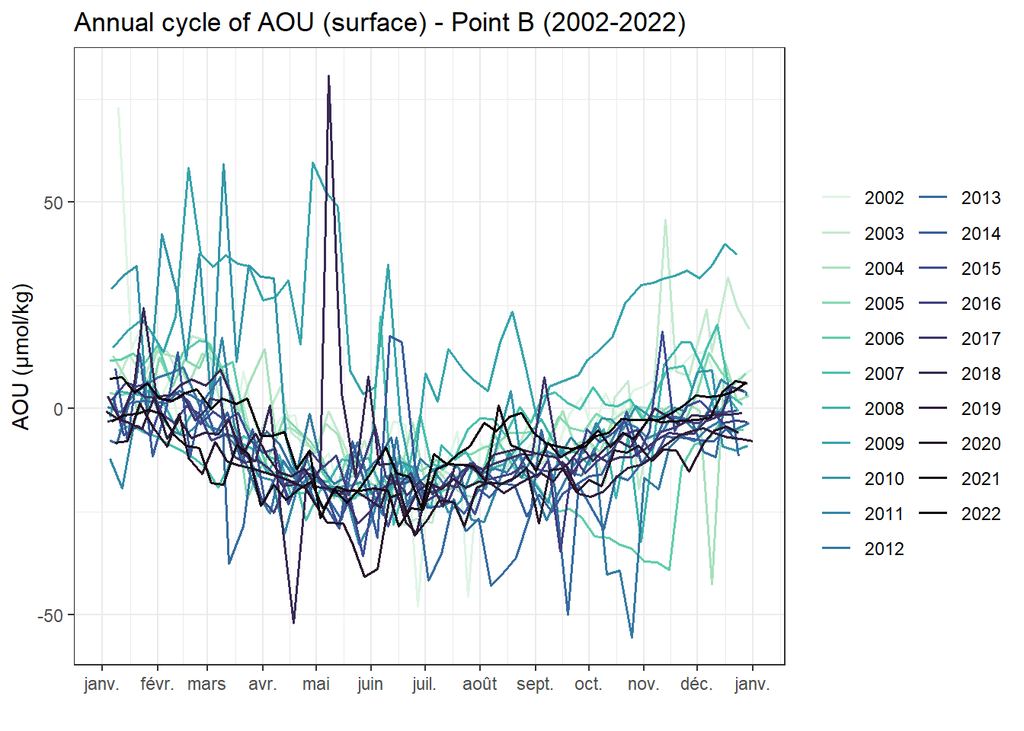

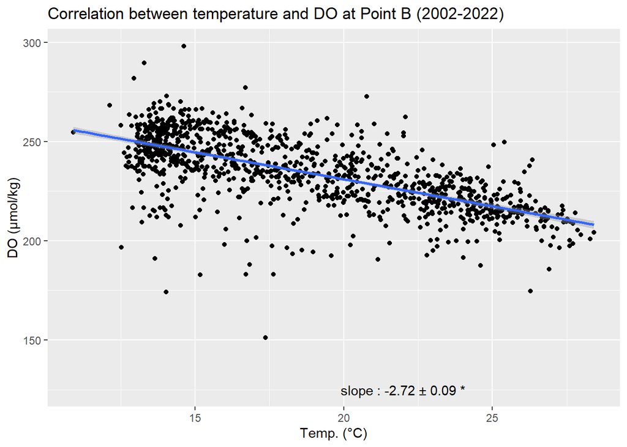

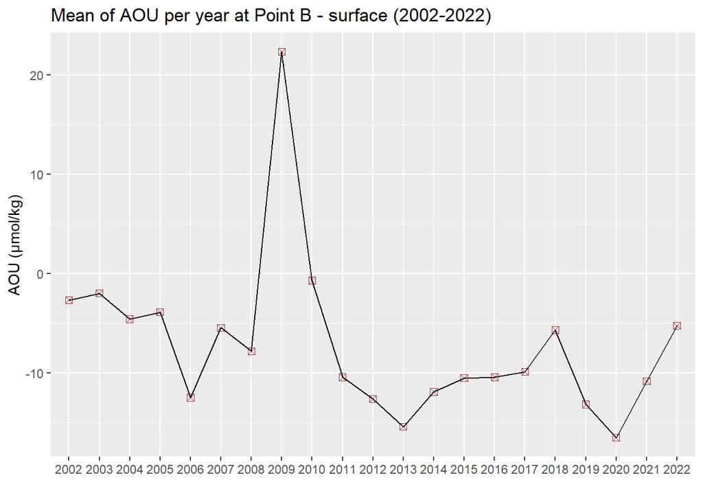

→ AOU (surface) minima and maxima evolution (2002-2022) :

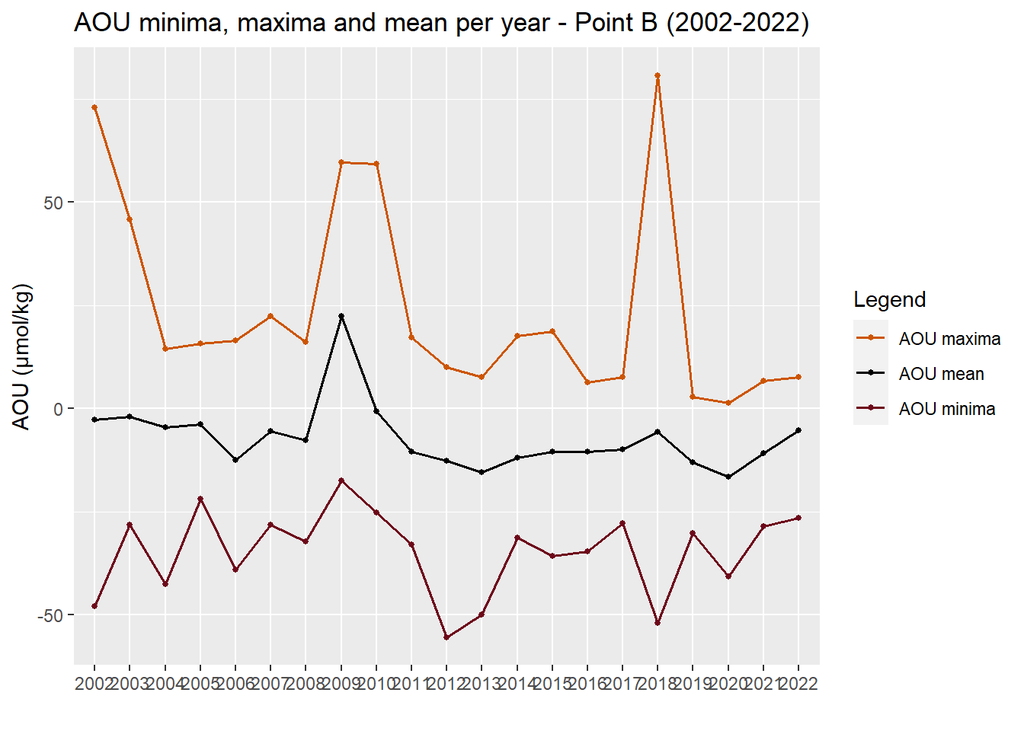

###### Trend analysis by residuals - AOU - surface (Bates et al. 2014) :

AOU : negative trend (Garcia et al., 2005)  
Inverse relation between AOU and observed O<sub>2</sub>  
*slope : -0.50 ± 0.060 µmol/kg par année*

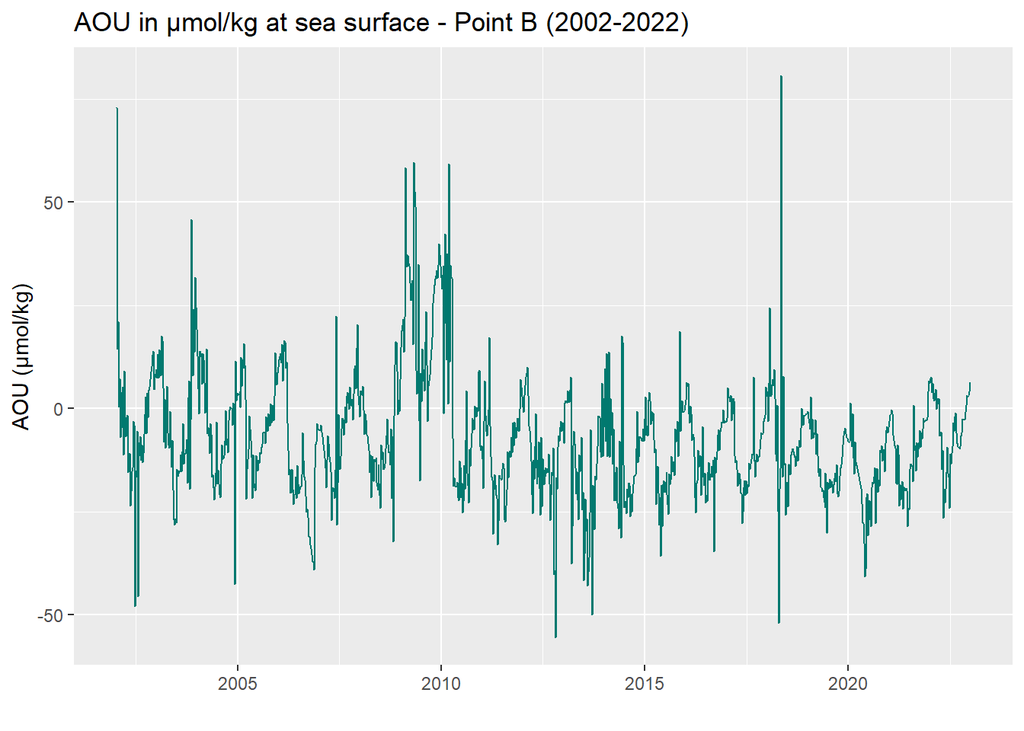

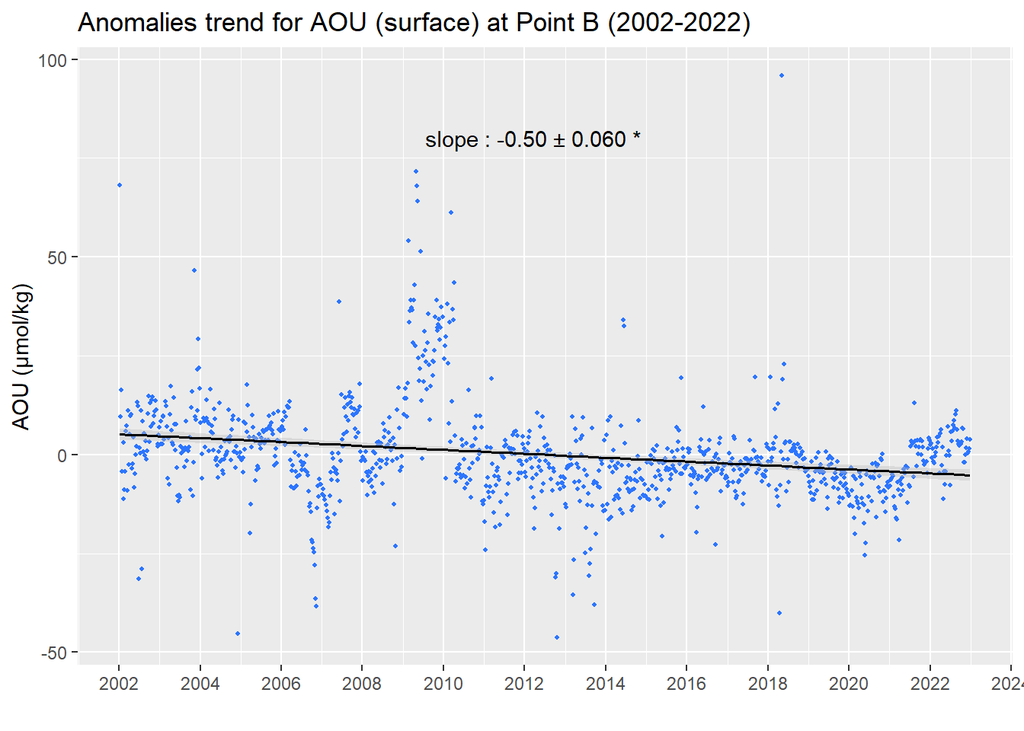

→ Plot mean annual anomalies of O<sub>2</sub>, O<sub>2</sub>sat and negative AOU (Mavropoulou et al., 2020)

Negative AOU and dissolved oxygen are similar in magnitude all over the period  
O<sub>2</sub>sat is close to zero  
DO and O<sub>2</sub>sat are similar in magnitude on 2 periods : 2002-2005 and 2011-2017

→ thus, out of these two periods, the solubility changes have a secondary role in the observed dissolved oxygen variations

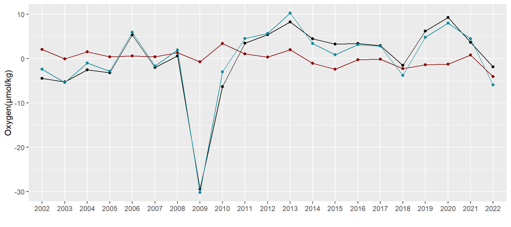

###### Trend analysis by moving average (decompose function) :

*Quick overview of the components of the series*

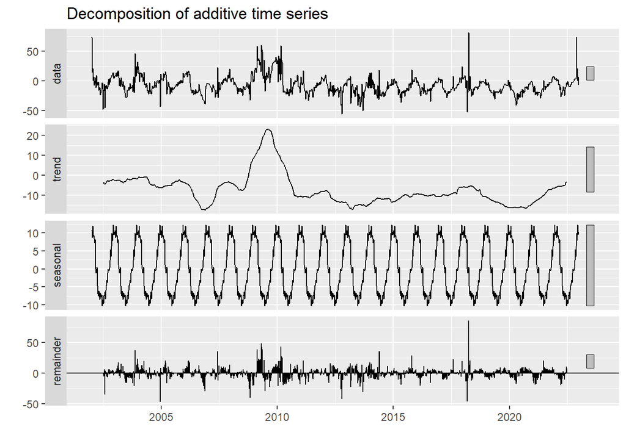

→ Remove seasonality :

measured values - seasonal pattern  
OR  
trend + remainders

*applying trend on the outputed series*

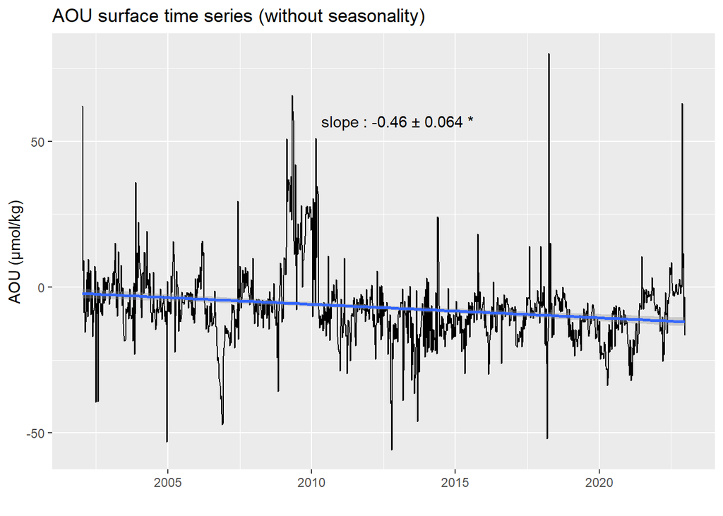

###### → 50 m data :

→ AOU (50m) annual cycle : low values in summer

Temperature and DO have a weak correlation, lower than in surface (r = -0.21) : when temp. increases, DO decreases

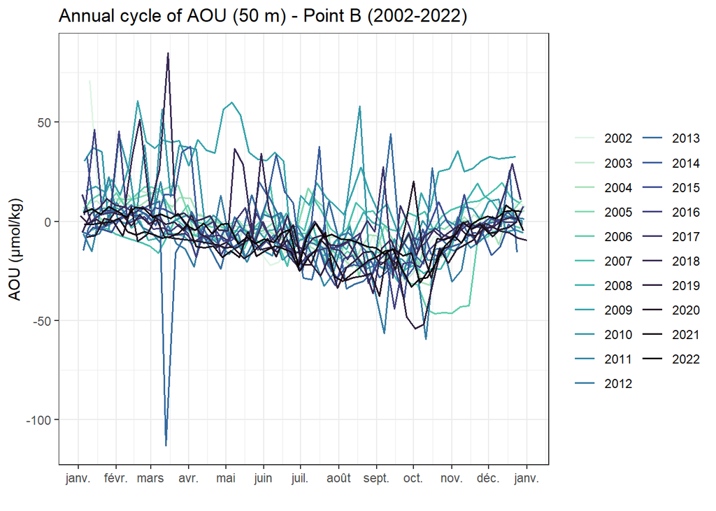

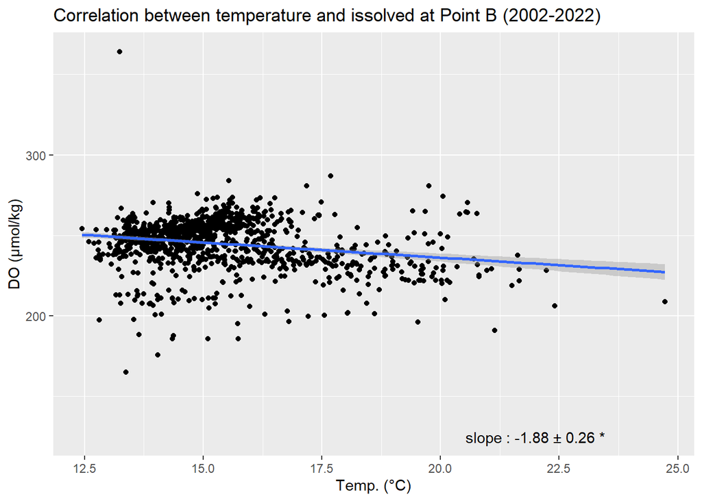

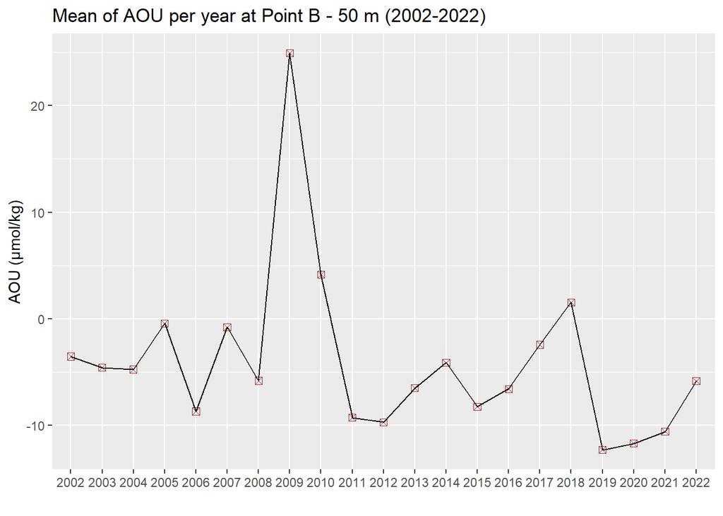

###### Trend analysis by residuals - AOU - 50m (Bates et al. 2014) :

AOU : negative trend, but less than in surface  
Inverse relation between AOU and observed O<sub>2</sub>  
*slope : -0.37 ± 0.07 µmol/kg par année*

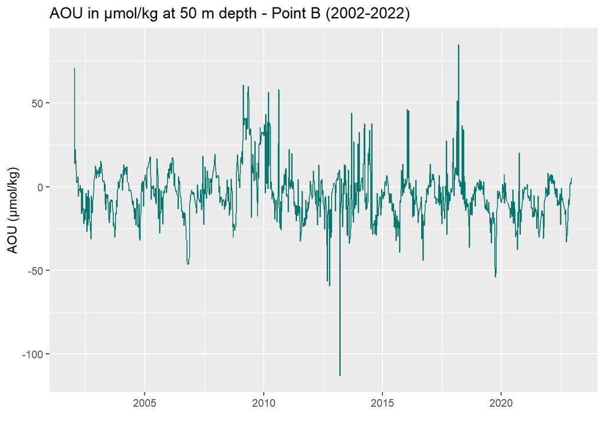

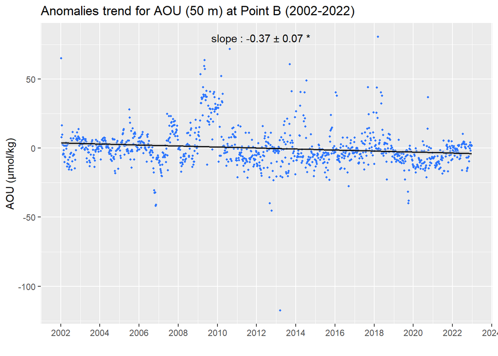

→ Plot mean annual anomalies of O<sub>2</sub>, O<sub>2</sub>sat and negative AOU (Mavropoulou et al., 2020)

Negative AOU and dissolved oxygen are similar in magnitude all over the period  
O<sub>2</sub>sat is close to zero  
DO and O<sub>2</sub>sat are similar in magnitude only for 2002-2004

→ thus, the solubility changes have a secondary role in the observed dissolved oxygen variations

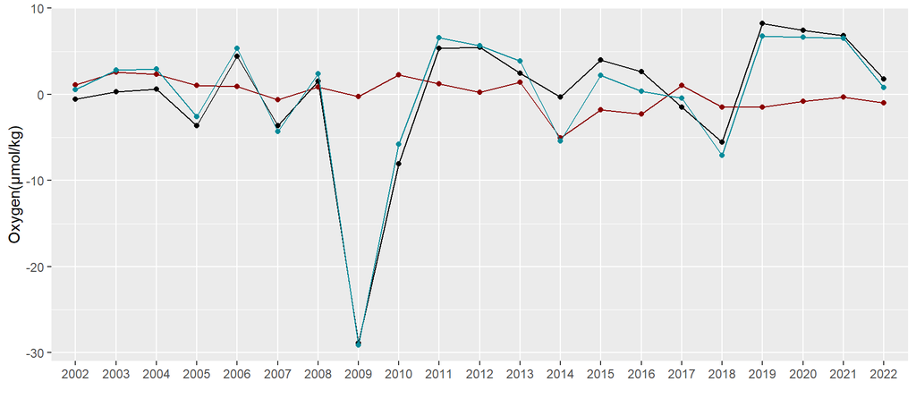

###### Trend analysis by moving average (decompose function) :

*Quick overview of the components of the series*

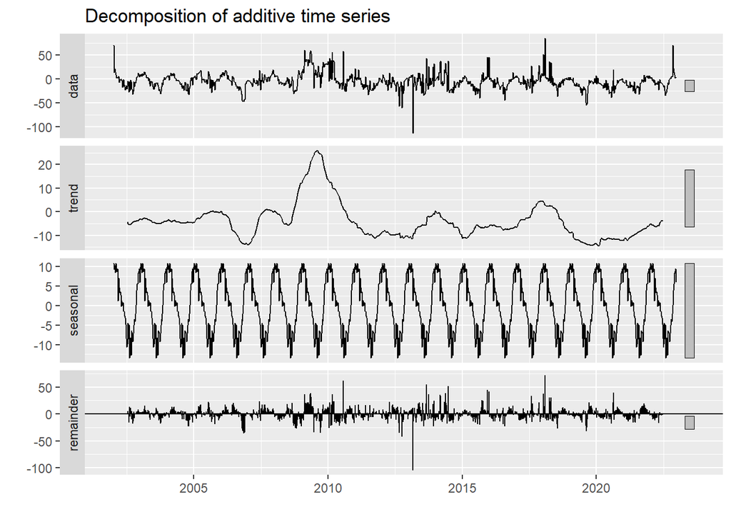

→ Remove seasonality :

*applying trend on the outputed series*

```
##
## Call:
## lm(formula = y ~ x, data = reg_val_AOU_prof_less_season)
##
## Residuals:
##      Min       1Q   Median       3Q      Max
## -110.070   -7.890   -1.660    5.376   79.991
##
## Coefficients:
##              Estimate Std. Error t value Pr(>|t|)
## (Intercept) 636.23599  144.99906   4.388 1.26e-05 ***
## x            -0.31809    0.07205  -4.415 1.11e-05 ***
## ---
## Signif. codes:  0 '***' 0.001 '**' 0.01 '*' 0.05 '.' 0.1 ' ' 1
##
## Residual standard error: 14.41 on 1089 degrees of freedom
## Multiple R-squared:  0.01758,    Adjusted R-squared:  0.01668
## F-statistic: 19.49 on 1 and 1089 DF,  p-value: 1.111e-05
```

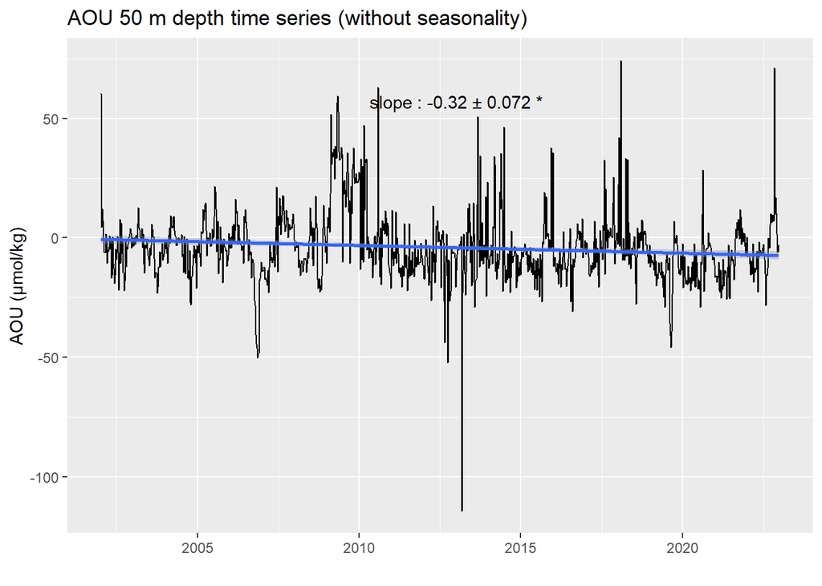